# RNA sequencing data exploration and quality assessment

Yifei Wan

Apirl/5/2018

## 1. 测序数据读入与整理

```r
rawdata <- read.csv2('LncRNA_all.txt', sep = '\t', row.names = 1)
```

接下来让我查看一下数据的基本结构：

```r
head(rawdata)
```

```
##                 Mod.1_count Mod.2_count Mod.3_count Treatment.1_count
## NONMMUT098608.1           1           2           1                 0
## NONMMUT016979.2         209         227         229               216
## NONMMUT136115.1          11          10          15                 4
## NONMMUT007474.2          35          49          35                42
## NONMMUT023875.2           3           3           3                 4
## NONMMUT026445.2           0           0           3                 1
##                 Treatment.2_count Treatment.3_count
## NONMMUT098608.1                 3                 2
## NONMMUT016979.2               240               191
## NONMMUT136115.1                 3                 4
## NONMMUT007474.2                41                40
## NONMMUT023875.2                 4                 3
## NONMMUT026445.2                 0                 0
```

可以清楚的从控制台返回的结果看出这是一个以lncRNA为行（row），以样本为列（column）的表格。列名略显凌乱，不方便之后的分析，让我们重新命名一下：

```r
conditions <- c(rep('control', 3), rep('treatment', 3)) ## 以实验条件作为列名
cols <- paste(conditions, 1:3, sep = '_')               ## 为各组编号
colnames(rawdata) <- cols                               ## 将新列名赋予原始表格
colnames(rawdata)                                       ## 打印新列名到控制台
```

```
## [1] "control_1"   "control_2"   "control_3"   "treatment_1" "treatment_2"
## [6] "treatment_3"
```

## 2. 数据的初步探索

我们会利用`ggplot2`包对原始数据进行可视化的探索，以求对数据的分布的有一个初步认识。可视化探索的结果会影响我们对后续策略的选择。 载入`ggplot2`:

```r
library(ggplot2)
```

### 2.1 直方图显示单个样本分布

直方图是最简单的作图方式之一，可以非常直观的展示数据的分布。下面我们以`control_1`为例绘制直方图：

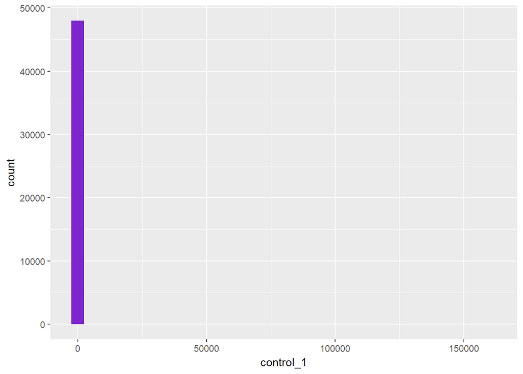

```r
ggplot(data = rawdata, aes(x = control_1)) +
  geom_histogram(fill = 'purple3', binwidth = 5000)
```

直方图呈现出一种奇怪的结果：几乎所有数据都挤在0附近的一根bar上面，而且肉眼可见的bar只有这一根。这就说明绝大多数的的测序结果都是很小的数字。但是如果对水平坐标轴进行观察，我们可以发现坐标轴横跨了从0到150,000的巨大区间。这暗示我们有稀少种类的RNA有远高于其他RNA的表达水平。这也符合我们大部分RNA表达水平较低而小部分RNA表达水平极高的假设（此假设是进行表达差异分析的基本假设）。 为了将种类少而表大量高的RNA也展示在直方图上，我们需要对数据整体进行转化（transformation），最常见的方式是取对数。但是因为数据中有0存在，所以为了避免出错需要对每一个数据点`+ 1`。当然也可以加其他合理小量。 完成转化之后重新绘图：

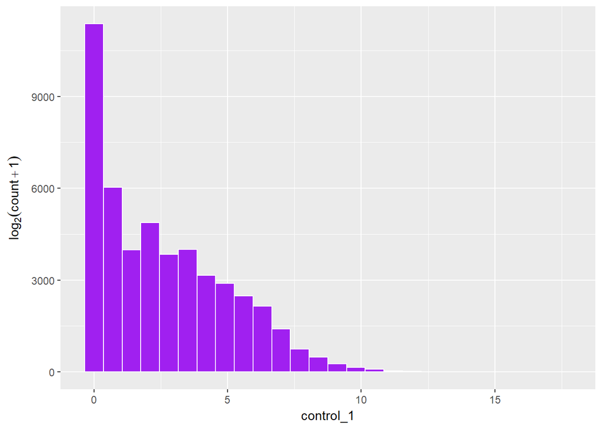

```r
logdata <- log2(rawdata + 1)                                        ## 对原始数据取对数
ggplot(data = logdata, aes(x = control_1)) +
  ylab(expression(log[2](count + 1))) +                             ## 使用新y-lab
  geom_histogram(colour = 'white', fill = 'purple', binwidth = 0.7) ## 添加白色包线
```

新直方图清晰的揭示了测序结果的分布情况也证明了我们上文的推测：表达水平高的RNA种类很少，绝大多数RNA都处于较低的表达水平换言之数据点极其分散。结合前文`head`命令所显示的原始数据，我们可以知道测序结果会是一种方差极大的离散数据（都是整数），这与microarray的连续数据（有非整数）有本质差异，也决定了后续分析方法将会不同。并且巨大的方差（过离散：overdispersion）导致过去测序分析中常见的泊松分布逐渐被负二项分布取代（泊松分布的期望和方差均等于其参数lambda, 这导致方差大小受限与数据实际情况不符）。 基于以上的结果，我们需要在后续的分析中对大量低表达数据进行过滤（filter）与移除，因为低表达数据无法与噪音相区隔会对分析过程造成误导。

### 2.2 箱形图探索组间分布差异

直方图展示了单组数据的分布，接下来我们需要探索组间的差异。箱形图可以将各组的的总体分布情况展示在同一途中，对于初步评估方差差异或观察实验与分析中的各种处理效应都有助益。需要注意的是ggplot的箱形图只接受两列的数据，所以需要对数据结构进行重构（reshape）。这里使用`reshape`包的`melt`函数：

```r
library(reshape)
boxdata <- melt(data = logdata, variable_name = 'Count')
```

```
## Using  as id variables
```

```r
head(boxdata)
```

```
##       Count    value
## 1 control_1 1.000000
## 2 control_1 7.714246
## 3 control_1 3.584963
## 4 control_1 5.169925
## 5 control_1 2.000000
## 6 control_1 0.000000
```

可以看出数据被重构为两列，第一列是数据来源的组别，第二列是对应的拷贝数。接下来作出箱形图：

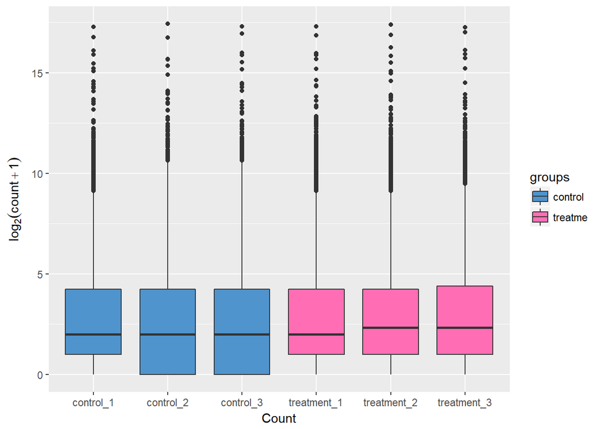

```r
groups <- substr(boxdata$Count, 1, 7)                               ## 标记数据组别来源的标签：treatment没用完整拼写
ggplot(data = boxdata, aes(x = Count, y = value, fill = groups)) +
  geom_boxplot() +
  ylab(expression(log[2](count + 1))) +
  scale_fill_manual(values = c('steelblue3', 'hotpink1'))
```

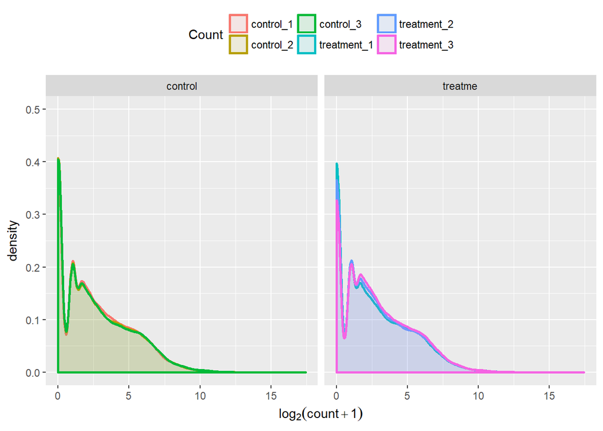

```r
boxdata <- data.frame(boxdata, condition = groups)                       ## 添加一列，将数据分为对照与处理两类
ggplot(data = boxdata, aes(x = value, colour = Count, fill = Count)) +   ## 以带序号的组名为准填充颜色和勾线
  ylim(c(0, 0.5)) +
  geom_density(alpha =0.1, size = 1) +                                   ## 参数alpha设置图像透明度，size设置勾线粗细
  facet_wrap(~ condition) +                                              ## 以刚才添加的分类为准分割图像为两框
  theme(legend.position = "top") +                                       ## 设置图注的位置
  xlab(expression(log[2](count + 1)))                                    ## 设置x轴标注
```

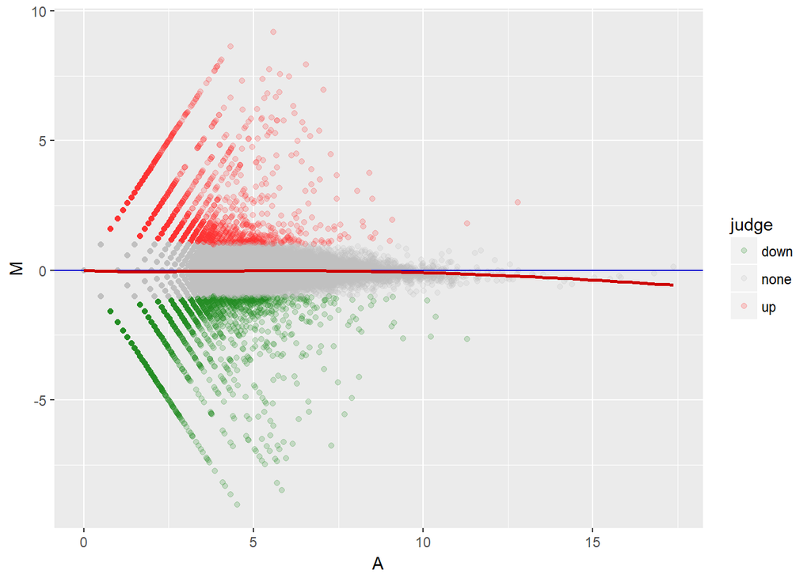

```r
M <- logdata$control_2 - logdata$treatment_1                        ## 计算对数表达差异倍数M-value
A <- (logdata$control_2 + logdata$treatment_1)/2                    ## 计算表达平均值
judge <- sapply(M, function(x , threshold = 1){                     ## 以±1为界根据表达上调或下调为表达差异分类为：up, down, none
  if(x > threshold){x = 'up'
  } else if (x < -threshold){x = 'down'
  } else {x = 'none'}
})

MA = data.frame(A, M)
ggplot(MA, aes(x = A, y = M)) +
  geom_point(aes(color=judge), size = 1.5, alpha = 1/5) +           ## 利用judge为数据点分类
  geom_hline(aes(yintercept=0), color = "blue3") +                  ## 添加水平线
  stat_smooth(se = FALSE, method = "loess", color = "red3") +       ## 添加趋势线（采用局部加权回归loess）
  scale_color_manual(values=c("forestgreen", "grey", "firebrick1")) ## 根据分类为数据点配色
```

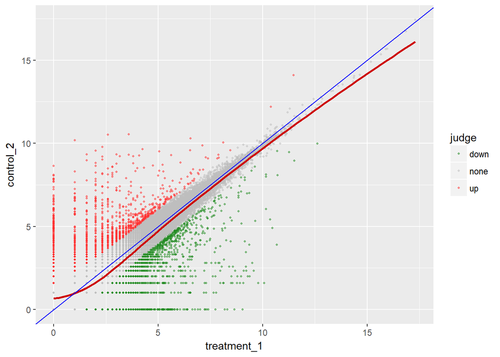

```r
ggplot(data = logdata, aes(x = treatment_1, y = control_2) ) +
  geom_point(aes(color=judge), alpha=1/2, size=0.8) +
  scale_color_manual(values=c("forestgreen", "grey", "firebrick1")) +
  geom_smooth(method = "loess",se = FALSE, colour = 'red3') +         ## 添加趋势线
  geom_abline(intercept = 0, slope = 1, colour = 'blue')              ## 添加对角线
```

```r
ggtitle('Scatter plot for log2fc')                                    ## 添加图片标题
```

```
## $title
## [1] "Scatter plot for log2fc"
##
## $subtitle
## NULL
##
## attr(,"class")
## [1] "labels"
```

散点图以两组参与比较的数据分别作为两轴，被减数control为y,减数treatment为x。此图的判读方法与MA图一致。趋势线同样显示数据需要归一化。